# Coursework Report

*N* removed NAs: 2

*N* removed <18: 17

*N* total clean: 130

| Group | *N* | *M*<sub>age</sub> | *M*<sub>rating</sub> |
| --- | --- | --- | --- |
| Control | 69 | 20.81 | 5.72 |
| Experim | 61 | 20.54 | 7.13 |

**Main analysis results**

*t*(128) = -9.79, *p* < .001

# Coursework Report

Analysing Data, Spring 2020

# Methods

## Participants

Table 1 *Descriptive statistics by condition*

[output not shown]

## Design

The conceptual hypothesis investigated in this experiment is ‘Does colour influence attractiveness?’. The operationalised independent variable being manipulated is the colour of the background behind a photo of a moderately attractive male, and the continuous dependent variable being measured is the ratings given on an attractiveness scale ranging from scores of 1 to 9 (1 meaning not at all attractive, and 9 meaning extremely attractive) collected for three different questions. The independent variable is a factor with two levels, with both a white background (used in the control condition), and a red background (used in the experimental condition) being displayed behind the photos presented to participants. The resulting operational hypothesis is ‘Does viewing a different colour background behind an image of a moderately attractive man influence the mean ratings of his attractiveness?’; this will be tested using statistical analysis via the use of a t-test.

# Results

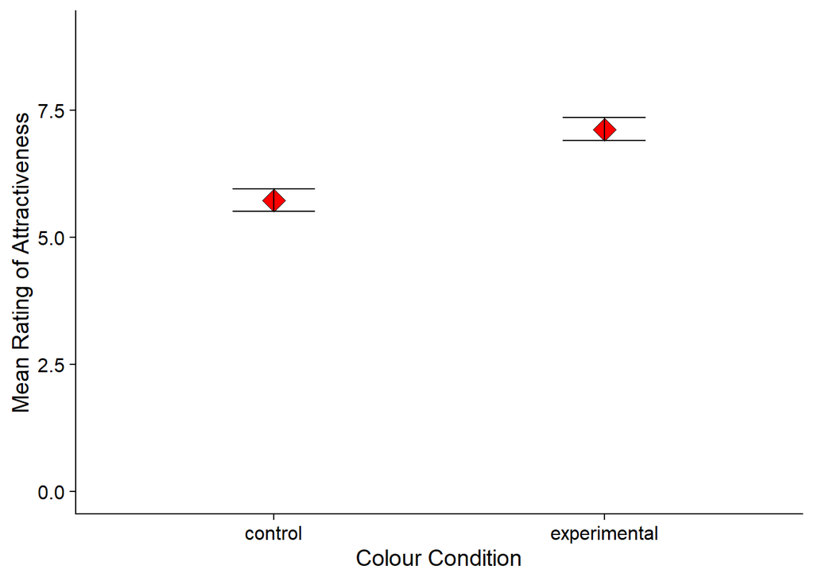

# Discussion

To summarise, the main findings of my experiment yielded a significant difference in the mean attractiveness ratings given by participants between control and experimental conditions, with the use of a red background resulting in the man in question being judged as more attractive than the same man displayed on a white background. In turn, this increases the likelihood that the change in attractiveness rating was due to the manipulation of background colour.

In terms of the contribution of these results to existing research in the field, Elliot et al’s (2010) original study also concluded a significant effect of the colour red on an increase in attractiveness ratings by participants; in fact, the mean ratings for control and experimental conditions in both the original experiment and my replication are notably similar. The use of a white background resulted in a mean totals of 5.67 (original study), and 5.72 (replication), and a red background yielded resulting means of 6.79 (original study) and 7.12 (replication). This may act as further support for the red effect defined in Elliot’s research, subsequently increasing the reliability of his findings considering the similarity of the means obtained in both studies.

However, it must not be ignored that several controversial replications have been conducted which may place the red effect in to question. For example, Hesslinger’s (2015) replication manipulating both background colour and the type of attire worn in the photos shown to participants failed to find a significant impact of the colour red on attractiveness ratings. Controversially, however, apparel type did appear to affect attraction with more formal clothing eliciting higher ratings; these findings both challenge the red effect and bring new concepts in to light, suggesting attraction may depend on the type of clothing actually worn as opposed to its colour. Furthermore, in one of Peperkoorn’s (2016) 3 experiments conducted to explore the relation of colour to attractiveness, no significant effect of a red t-shirt as opposed to a white or black t-shirt was found both in long and short term contexts. Although, despite colour having the smallest influence of participants’ evaluations of an individual, a white effect was interestingly found to influence perceptions of attractiveness as opposed to the more commonly researched red effect. The results obtained here clearly do not match the pattern of results from my experimental replication, suggesting there are other variables that can influence attractiveness besides the use of the colour red, potentially reducing the credibility of the ‘red effect’ concept considering the body of disputing evidence.

The independent groups design used acts as a strength of my experimental replication, due to the fact separate groups of participants were taking part in each condition meaning they could not gage the aims of the study as easily, resulting in reduced chances of demand characteristics occurring and thus validating my research further. In addition to this, attractiveness was measured via the use of 3 questions surrounding different aspects of attraction; this broader range of questioning may account for a potential change in levels of attraction depending on the question being asked, thus providing a more detailed and accurate account of attraction for each participant. On the other hand, in light of accurately replicating Elliot’s original experiment, only participants within the 18-25 bracket’s results were analysed, which is clearly not very generalisable and may not accurately reflect the population as the red effect may not have been found outside of this age range, reducing the external validity of my study as a result. As well as this, despite the between groups design reducing order effects, the design used carries the risk of individual differences confounding results; it is possible that the participants judging the man in front of a red background may have found him more attractive in the first place compared to the control group regardless of the background used, thus making it harder to establish a cause and effect mechanism between colour and attractiveness, consequently making it more difficult to validate the ‘red effect’. Based on my analysis, the significant results found hint to the prevalence of the red effect, especially considering the similarity of my results to Eliiot’s original experiment, suggesting one may perceive a man as more attractive when he is associated with the colour red. However, after reviewing further replications it is clear this effect cannot be accepted with open arms, particularly when considering the potential publication bias that Francis (2013) highlighted as a potential issue with Elliot’s research due to either null findings not being reported or improper running of experiments causing the null hypothesis to be wrongly rejected. This further questions the validity of Elliot’s research, suggesting the red effect is a phenomenon that should be investigated further.

If further research were to be conducted, it would be sensible to utilise a larger and more inclusive sample size in order to more accurately reflect the population as well as generalise the results found to a larger degree. Further research could also be inclusive of other variables such as attire considering the surprising results found from previous research; for example, in an attempt to distinguish whether the colour red or the attire itself if influencing attraction, a number of studies could be conducted whereby a man is photographed and judged in both formal and informal red clothing, as well as formal and informal clothing of a more commonly worn colour such as white or beige. It may also be interesting to look at the effects of red on variables other than attraction, such as interpretations of confidence or extraversion in order to explore the concept in more depth.

To conclude, the body of contrasting evidence paired with methodical issues suggests the red effect cannot be concluded with complete certainty, but the statistical significance of both Elliot’s original study and my replication can be used to at least infer its prominence in some cases, suggesting it may only be apparent in some situations as opposed to being a prevalent concept in every aspect of attraction. It is clear that there has been an array of exploration in to the red effect, so it may be the case that further rigorous experimentation is needed to confirm the true impact of the colour red on attraction.

# References

Elliot, A. J., Kayser, D. N., Greitemeyer, T., Lichtenfeld, S., Gramzow, R. H., Maier, M. A.,et al. (2010). Red, rank, and romance in women viewing men. J. Exp. Psychol. Gen.

Hesslinger, V.M., Goldbach, L. & Carbon, C. (2015) Men in red: A reexamination of the red-attractiveness effect.Psychon Bull Rev.22

Peperkoorn, L. S., Roberts, S. C., & Pollet, T. V. (2016). Revisiting the Red Effect on Attractiveness and Sexual Receptivity: No Effect of the Color Red on Human Mate Preferences.Evolutionary Psychology.

Francis, G. (2013). Publication bias in “Red, rank, and romance in women viewing men,” by elliot et al. (2010).Journal of Experimental Psychology: General,142(1)